# PML course project

Dmitry Sherbina

Saturday, October 25, 2014

load data and libraries

```r
library(caret); library(nlme); library(class)
D=read.csv('pml-training.csv')
T=read.csv('pml-testing.csv')
names(D)
```

```
##   [1] "X"                        "user_name"
##   [3] "raw_timestamp_part_1"     "raw_timestamp_part_2"
##   [5] "cvtd_timestamp"           "new_window"
##   [7] "num_window"               "roll_belt"
##   [9] "pitch_belt"               "yaw_belt"
##  [11] "total_accel_belt"         "kurtosis_roll_belt"
##  [13] "kurtosis_picth_belt"      "kurtosis_yaw_belt"
##  [15] "skewness_roll_belt"       "skewness_roll_belt.1"
##  [17] "skewness_yaw_belt"        "max_roll_belt"
##  [19] "max_picth_belt"           "max_yaw_belt"
##  [21] "min_roll_belt"            "min_pitch_belt"
##  [23] "min_yaw_belt"             "amplitude_roll_belt"
##  [25] "amplitude_pitch_belt"     "amplitude_yaw_belt"
##  [27] "var_total_accel_belt"     "avg_roll_belt"
##  [29] "stddev_roll_belt"         "var_roll_belt"
```

[output cut: 65 more lines]

```r
dim(D)
```

```
## [1] 19622   160
```

there are many variables (160) in data, some are strange: picth

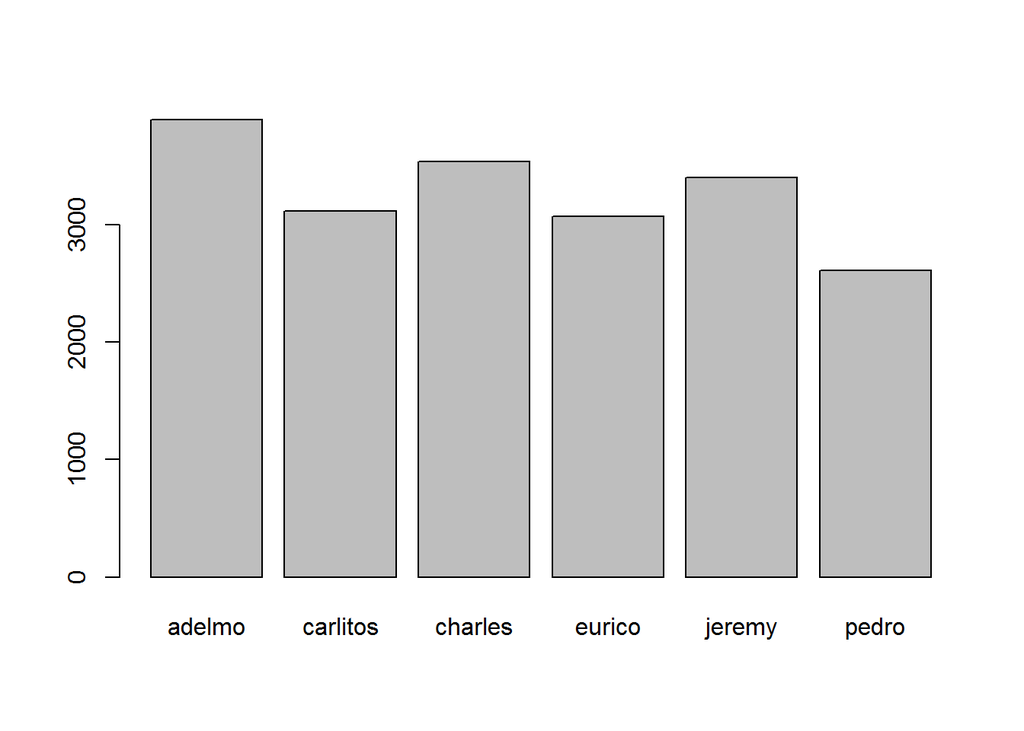

data of 6 users are relatively evenly distributed

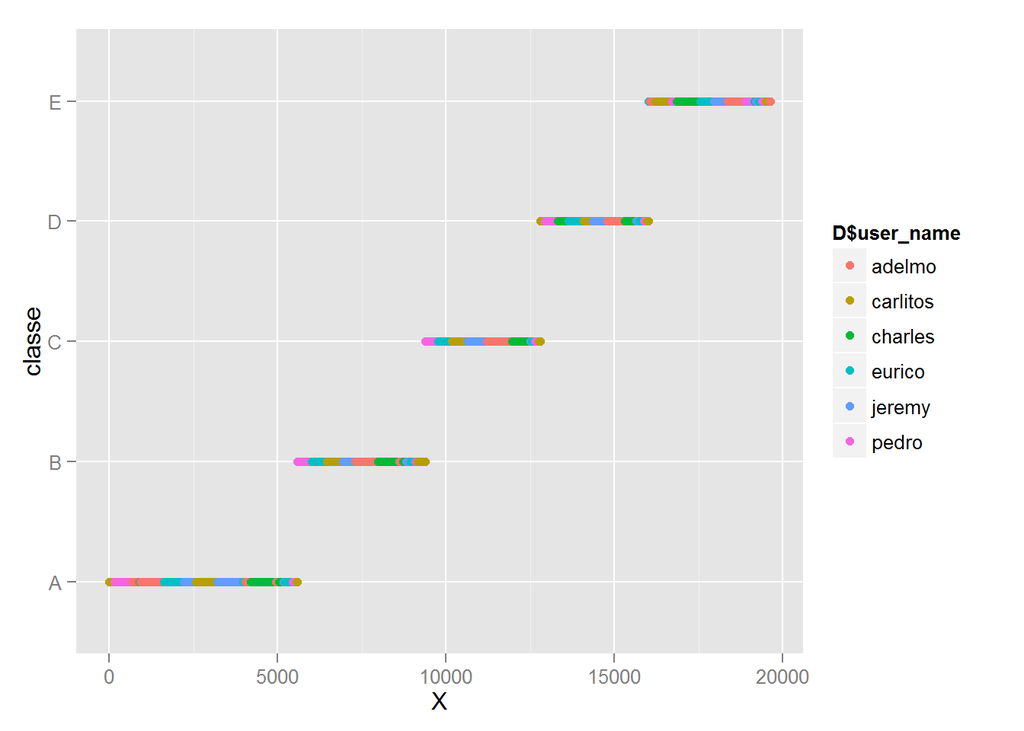

```r
qplot(X,classe, data = D, color=D$user_name)
```

samples in dataset are groupped by classe and user_name, but not strictly regular. Random sampling is ok for further slicing.

we want to predict one of five possible outcome in variable “classe”

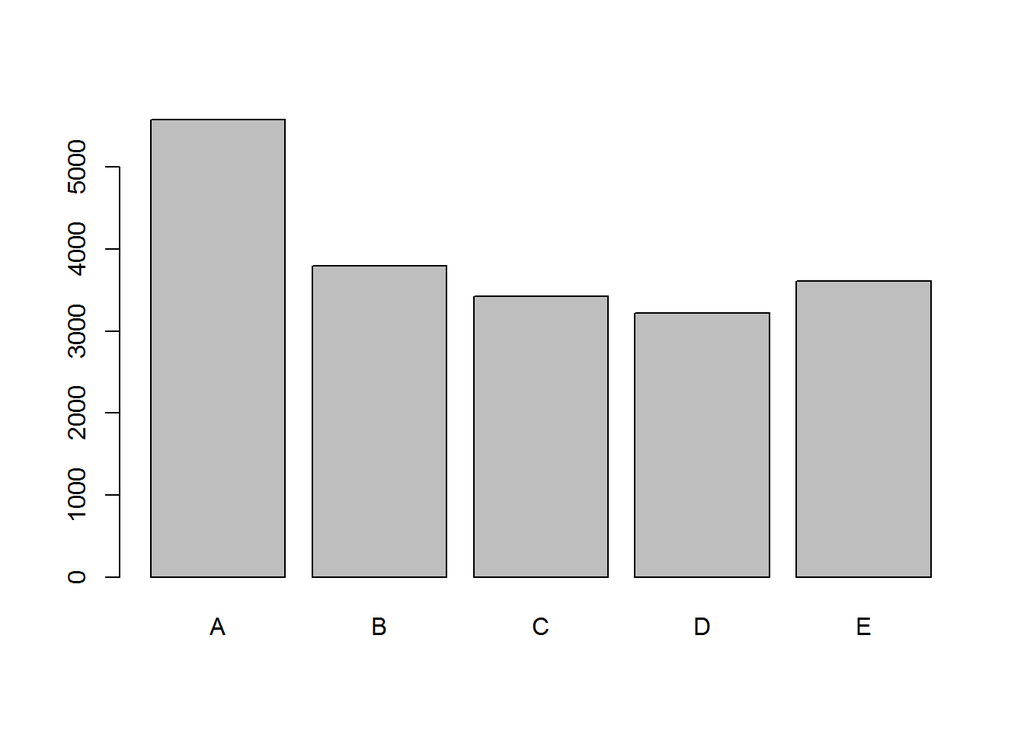

```r
plot(D$classe)
```

Classe A is most probable of them, but comparable, i.e. of the same order

## Preprocessing

change categorical output into numbers

```r
Out=predict(dummyVars(~classe, data=D),newdata=D)
head(Out)
```

```
##   classe.A classe.B classe.C classe.D classe.E
## 1        1        0        0        0        0
## 2        1        0        0        0        0
## 3        1        0        0        0        0
## 4        1        0        0        0        0
## 5        1        0        0        0        0
## 6        1        0        0        0        0
```

some variables seem not much useful for prediction, such X or raw.timestamp.part.1

```r
N=subset(D, select = -c(X, user_name, cvtd_timestamp, raw_timestamp_part_1, raw_timestamp_part_2, cvtd_timestamp,  new_window,  num_window, classe))
#N=data.frame(N,Out)
```

many variables are dependent of each other, for example space coordinates of body points, e.g. as seen for arm magnet

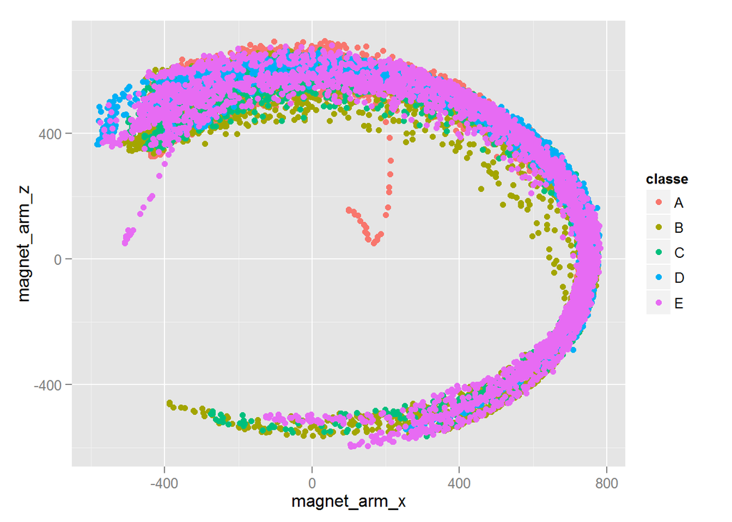

```r
qplot(magnet_arm_x,magnet_arm_z, data=D, color=classe)
```

```r
sum(complete.cases(N))/ dim(N)[1]
```

```
## [1] 0.02069106
```

so some dimension reduction will be useful, also remove near zero variated vars

```r
N=subset(N, select=!is.na(N[1,]))
nzv = nearZeroVar(N,saveMetrics=TRUE)
N=subset(N, select=!nzv$nzv)
```

to pick variables to include in a model we will use cross-validation later

now transform data to compensate outliers

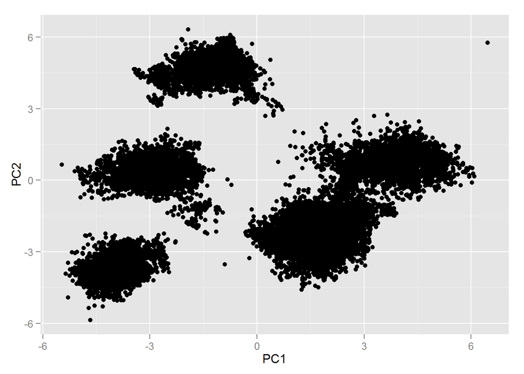

## Training

use training method - rpart - Tree-Based Model with cross-validation. This model is suited for categorical output without converting to indicator vars.

for 12 ICA: bayesglm(.3) widekernelpls(.45)

methods tried for 12 PC: (Accuracy) pls(.37) widekernelpls(.37) kernelpls(.37) rpart(.5) bayesglm(.32) simpls(.37) ?ctree (0.57) plr(.32 “Penalized Logistic Regression”)

```r
set.seed(555)
classe=D$classe
mo <- train(classe ~.,data=data.frame(N,classe), method="rpart", trControl = trainControl(method='cv')) #, preProcess=c('pca') )
mo
```

```
## CART
##
## 19622 samples
##    52 predictor
##     5 classes: 'A', 'B', 'C', 'D', 'E'
##
## No pre-processing
## Resampling: Cross-Validated (10 fold)
##
## Summary of sample sizes: 17660, 17659, 17660, 17658, 17659, 17662, ...
##
## Resampling results across tuning parameters:
##
##   cp      Accuracy  Kappa   Accuracy SD  Kappa SD
##   0.0357  0.511     0.3634  0.0229       0.0356
##   0.0600  0.429     0.2296  0.0655       0.1102
##   0.1152  0.316     0.0478  0.0404       0.0618
##
## Accuracy was used to select the optimal model using  the largest value.
## The final value used for the model was cp = 0.03567868.
```

```r
mo$finalModel
```

```
## n= 19622
##
## node), split, n, loss, yval, (yprob)
##       * denotes terminal node
##
##  1) root 19622 14042 A (0.28 0.19 0.17 0.16 0.18)
##    2) roll_belt< 130.5 17977 12411 A (0.31 0.21 0.19 0.18 0.11)
##      4) pitch_forearm< -33.95 1578    10 A (0.99 0.0063 0 0 0) *
##      5) pitch_forearm>=-33.95 16399 12401 A (0.24 0.23 0.21 0.2 0.12)
##       10) magnet_dumbbell_y< 439.5 13870  9953 A (0.28 0.18 0.24 0.19 0.11)
##         20) roll_forearm< 123.5 8643  5131 A (0.41 0.18 0.18 0.17 0.061) *
##         21) roll_forearm>=123.5 5227  3500 C (0.077 0.18 0.33 0.23 0.18) *
##       11) magnet_dumbbell_y>=439.5 2529  1243 B (0.032 0.51 0.043 0.22 0.19) *
##    3) roll_belt>=130.5 1645    14 E (0.0085 0 0 0 0.99) *
```

not able readily interpret residuals because of PCA, so the final version is w/o preprocessing

## Check

```r
R=predict(mo, T)
R
```

```
##  [1] C A C A A C C A A A C C C A C A A A A C
## Levels: A B C D E
```

```r
pml_write_files = function(x){
  n = length(x)
  for(i in 1:n){
    filename = paste0("problem_id_",i,".txt")
    write.table(x[i],file=filename,quote=FALSE,row.names=FALSE,col.names=FALSE)
  }
}
#pml_write_files(R)
```